# Cretu Dumitru, IS-211M, laboratory work nr. 1

```python
import numpy as np
import pandas as pd
import matplotlib.pyplot as plt
import tensorflow as ts
import matplotlib.pyplot as plt

import math
from keras.models import Sequential
from keras.layers import Dense
from keras.layers import LSTM
from sklearn.preprocessing import MinMaxScaler
from sklearn.metrics import mean_squared_error

np.random.seed(123)
ts.random.set_seed(123)
```

# Downloading the data (collecting `csv`)

```python
!wget -nc https://lazyprogrammer.me/course_files/airline_passengers.csv
```

```
File ‘airline_passengers.csv’ already there; not retrieving.
```

# Methods for data preparation

```python
def create_dataset(df,look_back):
    """
    perform separation of the data into X (input) and Y (output)
    IMPORTANT: slicing must be performed with iloc, because
    otherwise method will give error

    Args:
        df - dataframe separation of data for which is required
        look_back - how many records to keep in the input set,
                    after which comes one record for output set

    Return:
        tuple of arrays, where one is input set and another
        is output set, both transformed into Numpy arrays
    """
    data_x, data_y = [], []
    for index in range(len(df) - look_back - 1):
        a = df[index:(index+look_back)]
        data_x.append(a)
        data_y.append(df[index+look_back])
    return np.array(data_x), np.array(data_y)
```

```python
def split_data(x, y, test_size):
    """
    split input and output sets into training and testing one

    Args:
        x - input set
        y - output set
        test_size - size of the test set

    Return:
        4 elements (in the same sequence): input train,
        output train, input test and output test sets of data
    """
    #   position in the dataset, where will be performed
    # separation of dataset into training set and test
    # set
    pos = int(round(len(x) * (1 - test_size)))
    x_train, y_train = x[:pos], y[:pos]
    x_test, y_test = x[pos:], y[pos:]
    return x_train, y_train, x_test, y_test
```

# Loading the data into dataset

```python
airline_passengers_df = pd.read_csv("airline_passengers.csv")
airline_passengers_df.info()
airline_passengers_df
```

```
<class 'pandas.core.frame.DataFrame'>
RangeIndex: 144 entries, 0 to 143
Data columns (total 2 columns):
 #   Column      Non-Null Count  Dtype
---  ------      --------------  -----
 0   Month       144 non-null    object
 1   Passengers  144 non-null    int64
dtypes: int64(1), object(1)
memory usage: 2.4+ KB
```

|  | Month | Passengers |
| --- | --- | --- |
| 0 | 1949-01 | 112 |
| 1 | 1949-02 | 118 |
| 2 | 1949-03 | 132 |
| 3 | 1949-04 | 129 |
| 4 | 1949-05 | 121 |
| ... | ... | ... |
| 139 | 1960-08 | 606 |
| 140 | 1960-09 | 508 |
| 141 | 1960-10 | 461 |
| 142 | 1960-11 | 390 |
| 143 | 1960-12 | 432 |

144 rows × 2 columns

Considering the fact that first column covers only months when data samples were taken and that all records come in chronological uninterruptable manner first column can be ignored and it is possible to leave only indexes

# Data visualization and some basic analysis

```python
dataset = pd.read_csv('airline_passengers.csv', usecols=[1], engine='python')
dataset
```

|  | Passengers |
| --- | --- |
| 0 | 112 |
| 1 | 118 |
| 2 | 132 |
| 3 | 129 |
| 4 | 121 |
| ... | ... |
| 139 | 606 |
| 140 | 508 |
| 141 | 461 |
| 142 | 390 |
| 143 | 432 |

144 rows × 1 columns

So out of all the data there is only one column of data containing 144 records of the passengers count statuses

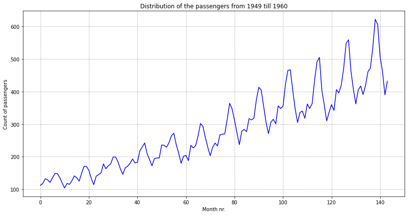

```python
fig, ax = plt.subplots(figsize=(14, 7))
ax.plot(airline_passengers_df.index, airline_passengers_df["Passengers"], color='b')
ax.set_xlabel("Month nr.")
ax.set_ylabel("Count of passengers")
ax.set_title("Distribution of the passengers from 1949 till 1960")
ax.grid(True, linestyle='--')
plt.show()
```

Even visually can be seen that there is a trend to slow increase count of passengers. Another moment is repetative (cyclical) manner of passengers count peaks. While the first aspect can be explained by inreasing number of international flights due to increase of jets/planes with decrease of price for such services (need to check), the second aspect can be explained by seasonality of the flights.

Seasonality means that there are many persons performing international flights during their vacation and therefore, considering that most of the people are taking vacation during Spring and Summer (need to check), distribution of the records will look cyclical with smaller peak around Spring and bigger peak around Summer.

To perform efficient analysis of the data it is required to remove the increasing trend and ensure data stability, after which model training can be performed

# Trend removal

Actions presented below allowed removal of the trend in data and now there is a problem of varying range of values. To solve this issue can be tried strategy of taking log of the passengers difference and sin of the passengers difference. Therefore, here will be performed comparison of those two approaches to see which one will lead to better results.

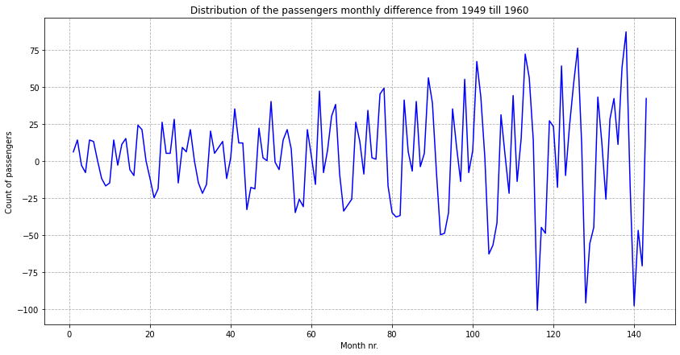

```python
airline_passengers_df["Fixed Passengers"] = airline_passengers_df["Passengers"] - airline_passengers_df["Passengers"].shift(1)

fig, ax = plt.subplots(figsize=(14, 7))
ax.plot(airline_passengers_df.index, airline_passengers_df["Fixed Passengers"], color='b')
ax.set_xlabel("Month nr.")
ax.set_ylabel("Count of passengers")
ax.set_title("Distribution of the passengers monthly difference from 1949 till 1960")
ax.grid(True, linestyle='--')
plt.show()
```

# Cycle removal

## Log approach

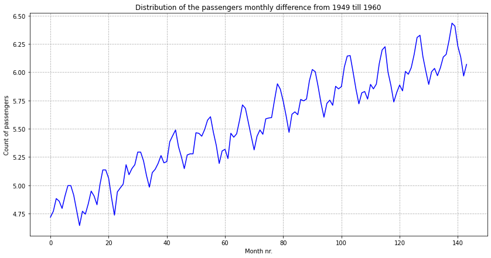

```python
airline_passengers_df["Log Passengers"] = np.log(airline_passengers_df["Passengers"])

fig, ax = plt.subplots(figsize=(14, 7))
ax.plot(airline_passengers_df.index, airline_passengers_df["Log Passengers"], color='b')
ax.set_xlabel("Month nr.")
ax.set_ylabel("Count of passengers")
ax.set_title("Distribution of the passengers monthly difference from 1949 till 1960")
ax.grid(True, linestyle='--')
plt.show()
```

Here can be seen that *log* operation performed reduce of the values range and stabilized distribution, but concept of cycles in data remained

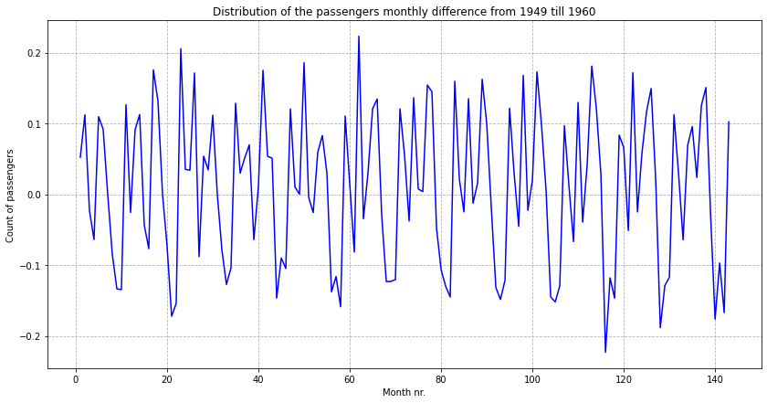

```python
airline_passengers_df["Log Diff Passengers"] = airline_passengers_df["Log Passengers"] - airline_passengers_df["Log Passengers"].shift(1)

fig, ax = plt.subplots(figsize=(14, 7))
ax.plot(airline_passengers_df.index, airline_passengers_df["Log Diff Passengers"], color='b')
ax.set_xlabel("Month nr.")
ax.set_ylabel("Count of passengers")
ax.set_title("Distribution of the passengers monthly difference from 1949 till 1960")
ax.grid(True, linestyle='--')
plt.show()
```

Application of the difference on top of the data where *log* was performed led to removal of the cycles and can be seen that behavior of the data has some similarities to the cyclical one, but much less

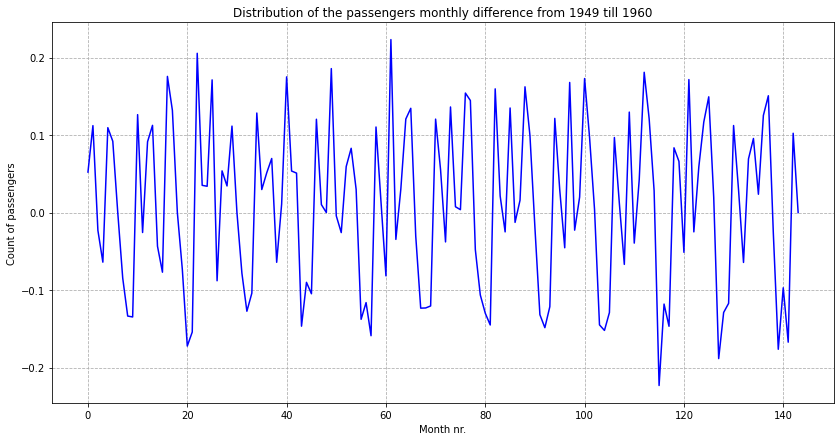

```python
airline_passengers_df["Log Np Diff Passengers"] = np.append(np.diff(airline_passengers_df["Log Passengers"]), 0)

fig, ax = plt.subplots(figsize=(14, 7))
ax.plot(airline_passengers_df.index, airline_passengers_df["Log Np Diff Passengers"], color='b')
ax.set_xlabel("Month nr.")
ax.set_ylabel("Count of passengers")
ax.set_title("Distribution of the passengers monthly difference from 1949 till 1960")
ax.grid(True, linestyle='--')
plt.show()
```

Here is presented the same concept of differentiation as in previous cell, but this time it is performed via numpy tools

## Sin approach

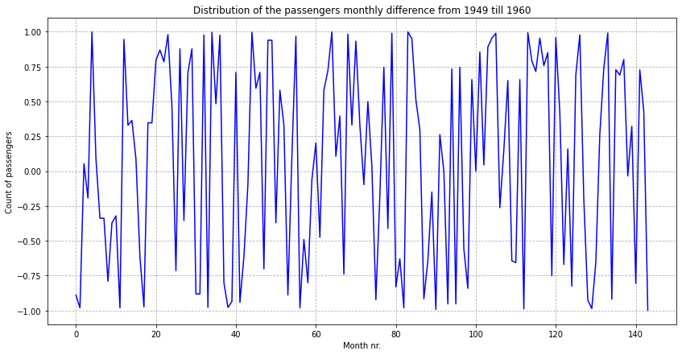

```python
airline_passengers_df["Sin Passengers"] = np.sin(airline_passengers_df["Passengers"])

fig, ax = plt.subplots(figsize=(14, 7))
ax.plot(airline_passengers_df.index, airline_passengers_df["Sin Passengers"], color='b')
ax.set_xlabel("Month nr.")
ax.set_ylabel("Count of passengers")
ax.set_title("Distribution of the passengers monthly difference from 1949 till 1960")
ax.grid(True, linestyle='--')
plt.show()
```

*Sin* function impact the original distribution and heavily changes it. In case of performing reverse operation it is possible to lose original range of values. It is possible to fix it temporarily via application of the MinMax scaler, but considering further possible increase of the passengers count it will be just a temporary solution or will require readaptation of the model to new data

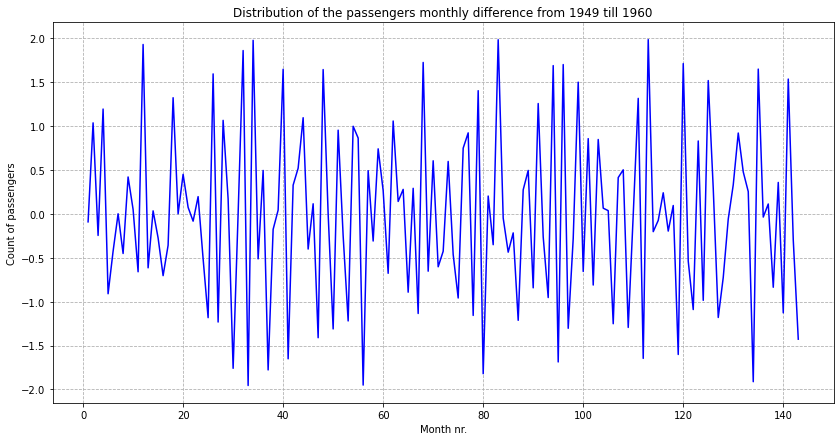

```python
airline_passengers_df["Sin Diff Passengers"] = airline_passengers_df["Sin Passengers"] - airline_passengers_df["Sin Passengers"].shift(1)

fig, ax = plt.subplots(figsize=(14, 7))
ax.plot(airline_passengers_df.index, airline_passengers_df["Sin Diff Passengers"], color='b')
ax.set_xlabel("Month nr.")
ax.set_ylabel("Count of passengers")
ax.set_title("Distribution of the passengers monthly difference from 1949 till 1960")
ax.grid(True, linestyle='--')
plt.show()
```

Current work will be performed with separation of the approaches to track which ones will lead to better results

# Initial LSTM check (no data changes, only MinMax scaler)

The original data can be used for performing predictions using LSTM. Considering that all other models were giving strange results it was decided to perform LSTM model predictions using the original data with MinMax scaling of the records.

All predcitions will be then transformed back to the original form using inverse operation. Another important moment is that compared to the laboratory work solution, where each 10 months where used to predict each 11-th month, here will be used concept of predicting next month value basing on the current one.

```python
data = dataset.values
data = data.astype('float32')
data[:10]
```

```
array([[112.],
       [118.],
       [132.],
       [129.],
       [121.],
       [135.],
       [148.],
       [148.],
       [136.],
       [119.]], dtype=float32)
```

```python
scaler = MinMaxScaler(feature_range=(0, 1))
data = scaler.fit_transform(data)
```

```python
train_size = int(len(data) * 0.67)
test_size = len(data) - train_size
train, test = data[0:train_size,:], data[train_size:len(data),:]
print(len(train), len(test))
```

```
96 48
```

```python
look_back = 1
trainX, trainY = create_dataset(train, look_back)
testX, testY = create_dataset(test, look_back)
```

```python
trainX = np.reshape(trainX, (trainX.shape[0], 1, trainX.shape[1]))
testX = np.reshape(testX, (testX.shape[0], 1, testX.shape[1]))
```

```python
model = Sequential()
model.add(LSTM(4, input_shape=(1, look_back)))
model.add(Dense(25))
model.compile(loss='mean_squared_error', optimizer='adam', metrics=['accuracy'])
# as a variant mean_squared_error
history = model.fit(trainX, trainY, epochs=100, validation_data=(testX, testY), batch_size=1, verbose=0)
```

```python
# make predictions
train_predict_pure = model.predict(trainX)
test_predict_pure = model.predict(testX)

# invert predictions
trainPredict = scaler.inverse_transform(train_predict_pure)
trainY = scaler.inverse_transform(trainY.reshape(len(trainY), 1))
testPredict = scaler.inverse_transform(test_predict_pure)
testY = scaler.inverse_transform(testY.reshape(len(testY), 1))

# calculate root mean squared error
trainScore = math.sqrt(mean_squared_error(trainY, trainPredict[:,0]))
print('Train Score: %.2f RMSE' % (trainScore))
testScore = math.sqrt(mean_squared_error(testY, testPredict[:,0]))
print('Test Score: %.2f RMSE' % (testScore))
```

```
Train Score: 22.78 RMSE
Test Score: 50.63 RMSE
```

Train and Test scores demonstrate relatively good error of the model. It is important to consider changing passengers count through time with trend of data to go up and up. Therefore, such rate demonstrates acceptable error.

```python
trainPredict
```

```
array([[119.94452 , 119.04923 , 119.90044 , ..., 119.23707 , 118.8762  ,
        119.54116 ],
       [125.10129 , 124.32459 , 125.06101 , ..., 124.487595, 124.19618 ,
        124.73989 ],
       [137.33026 , 136.82692 , 137.30113 , ..., 136.9327  , 136.77788 ,
        137.07793 ],
       ...,
       [390.11615 , 387.2584  , 389.86563 , ..., 387.85748 , 387.67007 ,
        388.33444 ],
       [346.11896 , 345.32205 , 346.07452 , ..., 345.4894  , 345.23615 ,
        345.72318 ],
       [300.81528 , 301.25266 , 300.8784  , ..., 301.1614  , 300.98166 ,
        301.1939  ]], dtype=float32)
```

```python
train_predict_df = pd.DataFrame(trainPredict[:,0])
test_predict_df = pd.DataFrame(testPredict[:,0])
predict_df = pd.concat([train_predict_df, test_predict_df])
predict_df.reset_index(inplace=True)
predict_df.drop(columns=["index"], inplace=True)
predict_df
```

|  | 0 |
| --- | --- |
| 0 | 119.944519 |
| 1 | 125.101288 |
| 2 | 137.330261 |
| 3 | 134.687531 |
| 4 | 127.699097 |
| ... | ... |
| 135 | 490.520203 |
| 136 | 545.666748 |
| 137 | 536.222656 |
| 138 | 471.453522 |
| 139 | 436.003540 |

140 rows × 1 columns

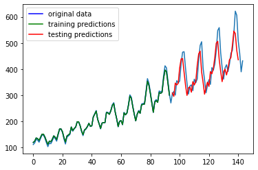

```python
# plot baseline and predictions
plt.plot(scaler.inverse_transform(data))
plt.plot(trainPredict[:,0], color='b', label="original data")
plt.plot(predict_df[:len(train_predict_df)].index, predict_df[:len(train_predict_df)][0], color="g",
         label='training predictions')
plt.plot(predict_df[len(train_predict_df):].index + 2,
         predict_df[len(train_predict_df):][0], color="r", label="testing predictions")
plt.legend()
plt.show()
```

Visually can be seen that predictions have small deviation from the original values. Model may have problems with going further through time and therefore it is possible to improve this model efficiency through some steps:

1. Improvement of the dataset via adding features influencing rise of passengers count (ticket price changes and so on);
2. Tuning the model;
3. Collecting more records

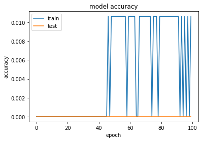

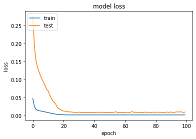

```python
plt.plot(history.history['accuracy'])
plt.plot(history.history['val_accuracy'])
plt.title('model accuracy')
plt.ylabel('accuracy')
plt.xlabel('epoch')
plt.legend(['train', 'test'], loc='upper left')
plt.show()

plt.plot(history.history['loss'])
plt.plot(history.history['val_loss'])
plt.title('model loss')
plt.ylabel('loss')
plt.xlabel('epoch')
plt.legend(['train', 'test'], loc='upper left')
plt.show()
```

What can be said in result? First of all, performing the LSTM over the original data gives relatively good results and can be seen that deviation of the predictions on the test set are not too far from the real ones and therefore efficiency of the model is relatively high. However, application of any change (new technology in flights, crisis, possible decrease of the ticket price) will lead to the heavy changes in distribution and therefore model will lose its efficiency.

Another problem is that there is a trend in the way how data behaves, meaning that distribution will progress through time and it is possible that model will not be able to "stay in touch" with trend.

To perform data adaptation, removing trend and possibly cycling of data it is possible to perform *log* operation in pair with differenciation. As one of the assumptions there was also provided *sin* operation, but there is one great problem with this operation - *sin* and any another trigonometric operation performs well with values in range from 0 to 1, but considering trend of data and how it distributes through time there will be values going out of the range (even transformed with MinMax scaler) and therefore application of the *sin* will lead to loss of data and then to errors in performing predictions.

The only option is to perform log difference. Considering that before this all the LSTM related work was performed with several deviations from the laboratory work conditions (for test was taken 1/3 of the dataset and `look_back` specified with value 1), it is required to demonstrate in the next chapter how will the data look in case of matching laboratory work conditions, but without the data transformations.

# LSTM check, laboratory work conditions met, but no data transformations (only minmax)

In this chapter will be demonstrated work with the original data, without application of any transformations, but with application of the "window" concept, when each 10 months are used to predict value of the 11-th month

```python
data = dataset.values
data = data.astype('float32')
data = scaler.fit_transform(data)
```

```python
train_size = int(len(data) * 0.9167)
test_size = len(data) - train_size
train, test = data[0:train_size,:], data[train_size:len(data),:]
print(len(train), len(test))
```

```
132 12
```

```python
look_back = 10
trainX, trainY = create_dataset(train, look_back)
testX, testY = create_dataset(test, look_back)
```

```python
trainX = np.reshape(trainX, (trainX.shape[0], 1, trainX.shape[1]))
testX = np.reshape(testX, (testX.shape[0], 1, testX.shape[1]))

model = Sequential()
model.add(LSTM(4, input_shape=(1, look_back)))
model.add(Dense(25))
model.compile(loss='mean_squared_error', optimizer='adam', metrics=['accuracy'])
history = model.fit(trainX, trainY, epochs=100, validation_data=(testX, testY), batch_size=1, verbose=2)

# make predictions
train_predict_pure = model.predict(trainX)
test_predict_pure = model.predict(testX)

# invert predictions
trainPredict = scaler.inverse_transform(train_predict_pure)
trainY = scaler.inverse_transform(trainY.reshape(len(trainY), 1))
testPredict = scaler.inverse_transform(test_predict_pure)
testY = scaler.inverse_transform(testY.reshape(len(testY), 1))

# calculate root mean squared error
trainScore = math.sqrt(mean_squared_error(trainY, trainPredict[:,0]))
print('Train Score: %.2f RMSE' % (trainScore))
testScore = math.sqrt(mean_squared_error(testY, testPredict[:,0]))
print('Test Score: %.2f RMSE' % (testScore))
```

[output not shown]

[output cut: 47 more lines]

[output not shown]

```python
train_predict_df
```

|  | 0 |
| --- | --- |
| 0 | 119.944519 |
| 1 | 125.101288 |
| 2 | 137.330261 |
| 3 | 134.687531 |
| 4 | 127.699097 |
| ... | ... |
| 89 | 363.141388 |
| 90 | 396.903320 |
| 91 | 390.116150 |
| 92 | 346.118958 |
| 93 | 300.815277 |

94 rows × 1 columns

```python
train_predict_df = pd.DataFrame(trainPredict[:,0])
test_predict_df = pd.DataFrame(testPredict[:,0])
predict_df = pd.concat([train_predict_df, test_predict_df])
predict_df.reset_index(inplace=True)
predict_df.drop(columns=["index"], inplace=True)
predict_df
```

|  | 0 |
| --- | --- |
| 0 | 118.335258 |
| 1 | 113.676613 |
| 2 | 128.787140 |
| 3 | 128.406525 |
| 4 | 129.944138 |
| ... | ... |
| 117 | 505.671661 |
| 118 | 488.064087 |
| 119 | 422.648651 |
| 120 | 361.931519 |
| 121 | 403.616028 |

122 rows × 1 columns

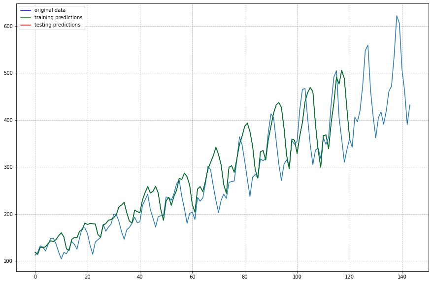

```python
# plot baseline and predictions
plt.figure(figsize=(15, 10))
plt.plot(scaler.inverse_transform(data))
plt.plot(trainPredict[:,0], color='b', label="original data")
plt.plot(predict_df[:len(train_predict_df)].index, predict_df[:len(train_predict_df)][0], color="g",
         label='training predictions')
plt.plot(predict_df[len(train_predict_df):].index,
         predict_df[len(train_predict_df):][0], color="r", label="testing predictions")
plt.legend()
plt.grid(True, linestyle='--')
plt.show()
```

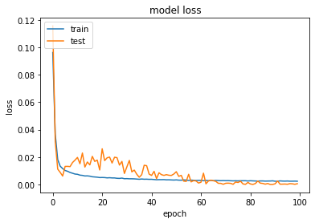

```python
plt.plot(history.history['accuracy'])
plt.plot(history.history['val_accuracy'])
plt.title('model accuracy')
plt.ylabel('accuracy')
plt.xlabel('epoch')
plt.legend(['train', 'test'], loc='upper left')
plt.show()

plt.plot(history.history['loss'])
plt.plot(history.history['val_loss'])
plt.title('model loss')
plt.ylabel('loss')
plt.xlabel('epoch')
plt.legend(['train', 'test'], loc='upper left')
plt.show()
```

[output not shown]

Next chapter demonstrates the same model, but this time with apploed `log difference` over the data to remove trend and stabilize distribution. Considering that it is required to make a `log` and then take a `difference` it will be required to store the first element of the dataset for further reconstruction of values.

So, the transformation will work like:

1. Take `log` of the each record;
2. Apply the differential over the data;

The backwards transformation will work like:

1. Reverse the differential, knowing the first element of the original dataset;
2. Find exponential of the record.

# LSTM laboratory work conditions met, log with differential applied

```python
data = dataset.values
data = data.astype('float32')
log_data = np.log(data)

log_diff_data = np.diff(log_data, axis=0)
```

```python
train_size = int(len(log_diff_data) * 0.9167)
test_size = len(log_diff_data) - train_size
train, test = log_diff_data[0:train_size,:], log_diff_data[train_size:len(log_diff_data),:]
print(len(train), len(test))

look_back = 10
trainX, trainY = create_dataset(train, look_back)
testX, testY = create_dataset(test, look_back)
```

```
131 12
```

```python
trainX = np.reshape(trainX, (trainX.shape[0], 1, trainX.shape[1]))
testX = np.reshape(testX, (testX.shape[0], 1, testX.shape[1]))

model = Sequential()
model.add(LSTM(4, input_shape=(1, look_back)))
model.add(Dense(25))
model.compile(loss='mean_squared_error', optimizer='adam', metrics=['accuracy'])
history = model.fit(trainX, trainY, epochs=100, validation_data=(testX, testY), batch_size=1, verbose=2)

# make predictions
train_predict_pure = model.predict(trainX)
test_predict_pure = model.predict(testX)
```

[output not shown]

[output cut: 45 more lines]

[output not shown]

```python
# calculate root mean squared error
trainScore = math.sqrt(mean_squared_error(trainY, train_predict_pure[:,0]))
print('Train Score: %.2f RMSE' % (trainScore))
testScore = math.sqrt(mean_squared_error(testY, test_predict_pure[:,0]))
print('Test Score: %.2f RMSE' % (testScore))
```

```
Train Score: 0.04 RMSE
Test Score: 0.08 RMSE
```

```python
train_predict_df = pd.DataFrame(train_predict_pure[:,0])
test_predict_df = pd.DataFrame(test_predict_pure[:,0])
predict_df = pd.concat([train_predict_df, test_predict_df])
predict_df.reset_index(inplace=True)
predict_df.drop(columns=["index"], inplace=True)
predict_df
```

|  | 0 |
| --- | --- |
| 0 | 0.133481 |
| 1 | 0.043338 |
| 2 | 0.037855 |
| 3 | 0.106400 |
| 4 | -0.048948 |
| ... | ... |
| 116 | 0.003986 |
| 117 | -0.183010 |
| 118 | -0.136130 |
| 119 | -0.166756 |
| 120 | -0.084647 |

121 rows × 1 columns

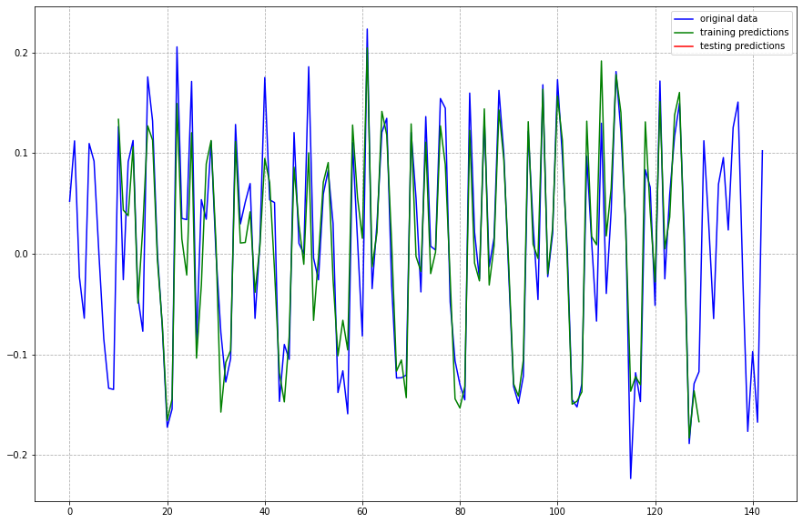

```python
# plot baseline and predictions
plt.figure(figsize=(15, 10))
plt.plot(log_diff_data, color='b', label="original data")
plt.plot(predict_df[:len(train_predict_df)].index + 10, predict_df[:len(train_predict_df)][0], color="g",
         label='training predictions')
plt.plot(predict_df[len(train_predict_df):].index,
         predict_df[len(train_predict_df):][0], color="r", label="testing predictions")
plt.legend()
plt.grid(True, linestyle='--')
plt.show()
```

In case of looking only at the logarithmically changed data with applied differentiation can be said that model performs great and there are small differences. This only looks so on the surface.

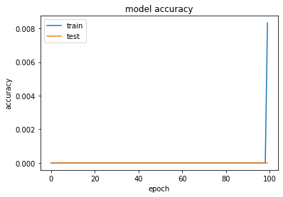

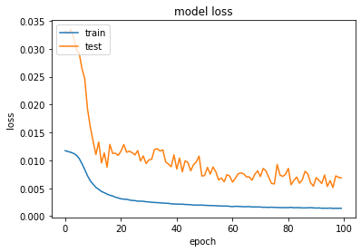

```python
plt.plot(history.history['accuracy'])
plt.plot(history.history['val_accuracy'])
plt.title('model accuracy')
plt.ylabel('accuracy')
plt.xlabel('epoch')
plt.legend(['train', 'test'], loc='upper left')
plt.show()

plt.plot(history.history['loss'])
plt.plot(history.history['val_loss'])
plt.title('model loss')
plt.ylabel('loss')
plt.xlabel('epoch')
plt.legend(['train', 'test'], loc='upper left')
plt.show()
```

```python
data = dataset.values
data = data.astype('float32')
log_data = np.log(data)

first_train_y = log_data[look_back]
# first_test_value = log_data[train_size]

train_predictions = train_predict_pure[:,0]
train_predictions = np.insert(train_predictions, 0, first_train_y)
train_predictions = np.exp(train_predictions.cumsum())

original_train_Y = trainY
original_train_Y = np.insert(original_train_Y, 0, first_train_y)
original_train_Y = np.exp(original_train_Y.cumsum())

trainScore = math.sqrt(mean_squared_error(original_train_Y, train_predictions))
print('Train Score: %.2f RMSE' % (trainScore))
```

```
Train Score: 87.93 RMSE
```

RMSE is relatively acceptable considering values closer to the end of the reviewed time period, but the problems start when looking at the difference between original dataset values and predicted ones

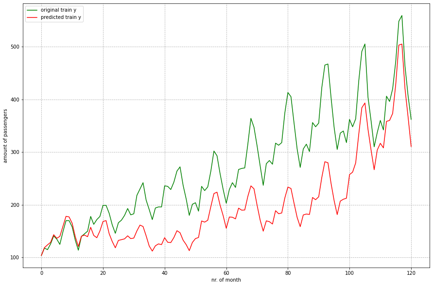

```python
plt.figure(figsize=(15, 10))
plt.plot(original_train_Y, color='g', label='original train y')
plt.plot(train_predictions, color='r', label='predicted train y')
plt.legend()
plt.xlabel("nr. of month")
plt.ylabel("amount of passengers")
plt.grid(True, linestyle='--')
plt.show()
```

While the original data contains trend with tendency to increasing passengers count, predictions behave with very similar shape of distribution, but it is like forced in and therefore there is a big difference between predictions and original data in the middle of taken time window

It is required to check approach if increased number of epoches will lead to better results (but there already is an overfit)

# LSTM (500 epoches) laboratory work conditions met, log with differential applied

```python
data = dataset.values
data = data.astype('float32')
log_data = np.log(data)

log_diff_data = np.diff(log_data, axis=0)

train_size = int(len(log_diff_data) * 0.9167)
test_size = len(log_diff_data) - train_size
train, test = log_diff_data[0:train_size,:], log_diff_data[train_size:len(log_diff_data),:]
print(len(train), len(test))

look_back = 10
trainX, trainY = create_dataset(train, look_back)
testX, testY = create_dataset(test, look_back)

trainX = np.reshape(trainX, (trainX.shape[0], 1, trainX.shape[1]))
testX = np.reshape(testX, (testX.shape[0], 1, testX.shape[1]))

model = Sequential()
model.add(LSTM(4, input_shape=(1, look_back)))
model.add(Dense(25))
model.compile(loss='mean_squared_error', optimizer='adam', metrics=['accuracy'])
history = model.fit(trainX, trainY, epochs=500, validation_data=(testX, testY), batch_size=1, verbose=2)

# make predictions
train_predict_pure = model.predict(trainX)
test_predict_pure = model.predict(testX)
```

[output not shown]

[output cut: 446 more lines]

[output not shown]

```
Train Score: 0.03 RMSE
Test Score: 0.07 RMSE
```

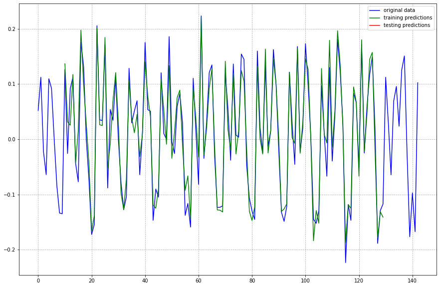

```python
# calculate root mean squared error
trainScore = math.sqrt(mean_squared_error(trainY, train_predict_pure[:,0]))
print('Train Score: %.2f RMSE' % (trainScore))
testScore = math.sqrt(mean_squared_error(testY, test_predict_pure[:,0]))
print('Test Score: %.2f RMSE' % (testScore))

train_predict_df = pd.DataFrame(train_predict_pure[:,0])
test_predict_df = pd.DataFrame(test_predict_pure[:,0])
predict_df = pd.concat([train_predict_df, test_predict_df])
predict_df.reset_index(inplace=True)
predict_df.drop(columns=["index"], inplace=True)

# plot baseline and predictions
plt.figure(figsize=(15, 10))
plt.plot(log_diff_data, color='b', label="original data")
plt.plot(predict_df[:len(train_predict_df)].index + 10, predict_df[:len(train_predict_df)][0], color="g",
         label='training predictions')
plt.plot(predict_df[len(train_predict_df):].index,
         predict_df[len(train_predict_df):][0], color="r", label="testing predictions")
plt.legend()
plt.grid(True, linestyle='--')
plt.show()
```

Model makes great match of predictions to the transformed original data, but it is required to check behavior in the original form of data

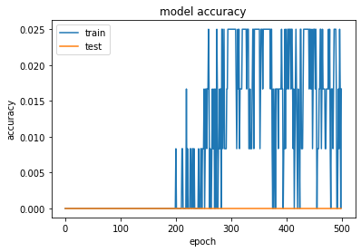

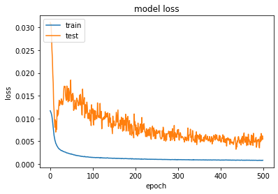

```python
plt.plot(history.history['accuracy'])
plt.plot(history.history['val_accuracy'])
plt.title('model accuracy')
plt.ylabel('accuracy')
plt.xlabel('epoch')
plt.legend(['train', 'test'], loc='upper left')
plt.show()

plt.plot(history.history['loss'])
plt.plot(history.history['val_loss'])
plt.title('model loss')
plt.ylabel('loss')
plt.xlabel('epoch')
plt.legend(['train', 'test'], loc='upper left')
plt.show()
```

```
Train Score: 84.92 RMSE
```

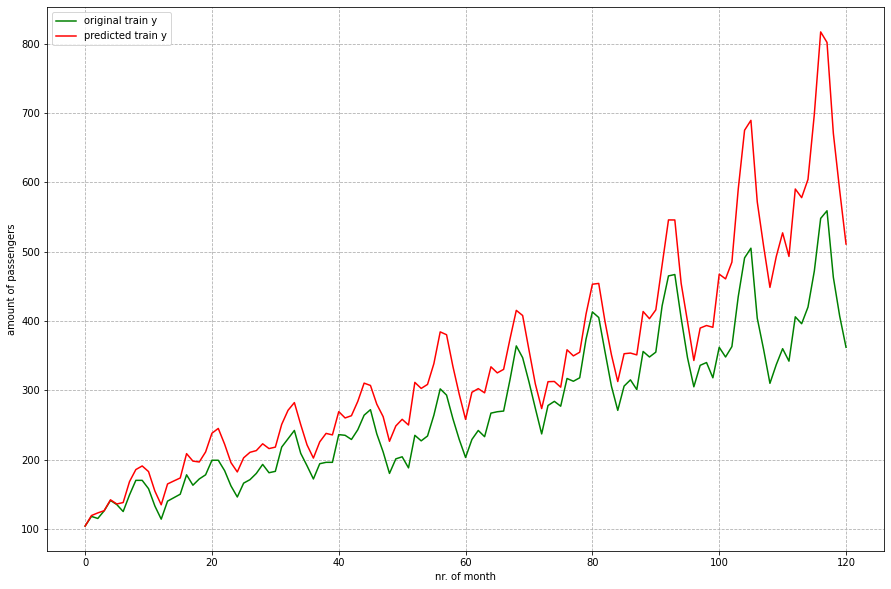

```python
data = dataset.values
data = data.astype('float32')
log_data = np.log(data)

first_train_y = log_data[look_back]
# first_test_value = log_data[train_size]

train_predictions = train_predict_pure[:,0]
train_predictions = np.insert(train_predictions, 0, first_train_y)
train_predictions = np.exp(train_predictions.cumsum())

original_train_Y = trainY
original_train_Y = np.insert(original_train_Y, 0, first_train_y)
original_train_Y = np.exp(original_train_Y.cumsum())

trainScore = math.sqrt(mean_squared_error(original_train_Y, train_predictions))
print('Train Score: %.2f RMSE' % (trainScore))

plt.figure(figsize=(15, 10))
plt.plot(original_train_Y, color='g', label='original train y')
plt.plot(train_predictions, color='r', label='predicted train y')
plt.legend()
plt.xlabel("nr. of month")
plt.ylabel("amount of passengers")
plt.grid(True, linestyle='--')
plt.show()
```

In this case model achieves almost the same RMSE, but distribution differs from one received in the last model. Here predictions are above original values, but overall shape is still almost identical. And overfit of the model considering lossses is heavy.

Increasing number of the epoches has not given any good result and therefore it will be great to check inreasing number of layers for model and experiment with number of neurons per layer.

# LSTM two layers, 50 neurons, 100 epoches, log with differential applied

```python
data = dataset.values
data = data.astype('float32')
log_data = np.log(data)

log_diff_data = np.diff(log_data, axis=0)

train_size = int(len(log_diff_data) * 0.9167)
test_size = len(log_diff_data) - train_size
train, test = log_diff_data[0:train_size,:], log_diff_data[train_size:len(log_diff_data),:]
print(len(train), len(test))

look_back = 10
trainX, trainY = create_dataset(train, look_back)
testX, testY = create_dataset(test, look_back)

trainX = np.reshape(trainX, (trainX.shape[0], 1, trainX.shape[1]))
testX = np.reshape(testX, (testX.shape[0], 1, testX.shape[1]))

model = Sequential()
# model.add(LSTM(4, input_shape=(1, look_back)))
model.add(LSTM(4, batch_input_shape=(1, 1, look_back), stateful=True, return_sequences=True))
model.add(Dense(50))
model.add(LSTM(4, batch_input_shape=(1, 1, look_back), stateful=True))
model.add(Dense(50))
model.compile(loss='mean_squared_error', optimizer='adam', metrics=['accuracy'])
history = model.fit(trainX, trainY, epochs=100, validation_data=(testX, testY), batch_size=1, verbose=2)

# make predictions
train_predict_pure = model.predict(trainX, batch_size=1)
test_predict_pure = model.predict(testX, batch_size=1)
```

```
131 12
120/120 - 5s - loss: 0.0117 - accuracy: 0.0000e+00 - val_loss: 0.0317 - val_accuracy: 0.0000e+00 - 5s/epoch - 40ms/step
120/120 - 0s - loss: 0.0116 - accuracy: 0.0000e+00 - val_loss: 0.0334 - val_accuracy: 0.0000e+00 - 297ms/epoch - 2ms/step
120/120 - 0s - loss: 0.0117 - accuracy: 0.0000e+00 - val_loss: 0.0333 - val_accuracy: 0.0000e+00 - 298ms/epoch - 2ms/step
120/120 - 0s - loss: 0.0116 - accuracy: 0.0000e+00 - val_loss: 0.0323 - val_accuracy: 0.0000e+00 - 293ms/epoch - 2ms/step
120/120 - 0s - loss: 0.0116 - accuracy: 0.0000e+00 - val_loss: 0.0300 - val_accuracy: 0.0000e+00 - 300ms/epoch - 3ms/step
120/120 - 1s - loss: 0.0116 - accuracy: 0.0083 - val_loss: 0.0307 - val_accuracy: 0.0000e+00 - 813ms/epoch - 7ms/step
120/120 - 0s - loss: 0.0115 - accuracy: 0.0000e+00 - val_loss: 0.0288 - val_accuracy: 0.0000e+00 - 441ms/epoch - 4ms/step
120/120 - 0s - loss: 0.0108 - accuracy: 0.0000e+00 - val_loss: 0.0330 - val_accuracy: 0.0000e+00 - 299ms/epoch - 2ms/step
120/120 - 0s - loss: 0.0077 - accuracy: 0.0000e+00 - val_loss: 0.0220 - val_accuracy: 0.0000e+00 - 301ms/epoch - 3ms/step
120/120 - 0s - loss: 0.0061 - accuracy: 0.0000e+00 - val_loss: 0.0100 - val_accuracy: 0.0000e+00 - 300ms/epoch - 3ms/step
120/120 - 0s - loss: 0.0053 - accuracy: 0.0000e+00 - val_loss: 0.0106 - val_accuracy: 0.0000e+00 - 307ms/epoch - 3ms/step
120/120 - 0s - loss: 0.0047 - accuracy: 0.0000e+00 - val_loss: 0.0029 - val_accuracy: 0.0000e+00 - 295ms/epoch - 2ms/step
120/120 - 0s - loss: 0.0045 - accuracy: 0.0000e+00 - val_loss: 0.0076 - val_accuracy: 0.0000e+00 - 310ms/epoch - 3ms/step
120/120 - 0s - loss: 0.0041 - accuracy: 0.0000e+00 - val_loss: 0.0080 - val_accuracy: 0.0000e+00 - 295ms/epoch - 2ms/step
120/120 - 0s - loss: 0.0040 - accuracy: 0.0000e+00 - val_loss: 0.0074 - val_accuracy: 0.0000e+00 - 288ms/epoch - 2ms/step
120/120 - 0s - loss: 0.0039 - accuracy: 0.0000e+00 - val_loss: 0.0125 - val_accuracy: 0.0000e+00 - 329ms/epoch - 3ms/step
120/120 - 0s - loss: 0.0035 - accuracy: 0.0000e+00 - val_loss: 0.0131 - val_accuracy: 0.0000e+00 - 306ms/epoch - 3ms/step
120/120 - 0s - loss: 0.0036 - accuracy: 0.0000e+00 - val_loss: 0.0092 - val_accuracy: 0.0000e+00 - 297ms/epoch - 2ms/step
120/120 - 0s - loss: 0.0038 - accuracy: 0.0000e+00 - val_loss: 0.0065 - val_accuracy: 0.0000e+00 - 301ms/epoch - 3ms/step
120/120 - 0s - loss: 0.0036 - accuracy: 0.0000e+00 - val_loss: 0.0087 - val_accuracy: 0.0000e+00 - 296ms/epoch - 2ms/step
120/120 - 0s - loss: 0.0033 - accuracy: 0.0000e+00 - val_loss: 0.0138 - val_accuracy: 0.0000e+00 - 300ms/epoch - 3ms/step
120/120 - 0s - loss: 0.0029 - accuracy: 0.0000e+00 - val_loss: 0.0073 - val_accuracy: 0.0000e+00 - 286ms/epoch - 2ms/step
120/120 - 0s - loss: 0.0033 - accuracy: 0.0000e+00 - val_loss: 0.0154 - val_accuracy: 0.0000e+00 - 324ms/epoch - 3ms/step
120/120 - 0s - loss: 0.0036 - accuracy: 0.0000e+00 - val_loss: 0.0171 - val_accuracy: 0.0000e+00 - 306ms/epoch - 3ms/step
120/120 - 0s - loss: 0.0033 - accuracy: 0.0000e+00 - val_loss: 0.0068 - val_accuracy: 0.0000e+00 - 296ms/epoch - 2ms/step
120/120 - 0s - loss: 0.0032 - accuracy: 0.0000e+00 - val_loss: 0.0096 - val_accuracy: 0.0000e+00 - 311ms/epoch - 3ms/step
120/120 - 0s - loss: 0.0030 - accuracy: 0.0000e+00 - val_loss: 0.0138 - val_accuracy: 0.0000e+00 - 310ms/epoch - 3ms/step
120/120 - 0s - loss: 0.0032 - accuracy: 0.0000e+00 - val_loss: 0.0128 - val_accuracy: 0.0000e+00 - 303ms/epoch - 3ms/step
120/120 - 0s - loss: 0.0029 - accuracy: 0.0000e+00 - val_loss: 0.0058 - val_accuracy: 0.0000e+00 - 299ms/epoch - 2ms/step
120/120 - 0s - loss: 0.0029 - accuracy: 0.0000e+00 - val_loss: 0.0047 - val_accuracy: 0.0000e+00 - 296ms/epoch - 2ms/step
120/120 - 0s - loss: 0.0028 - accuracy: 0.0000e+00 - val_loss: 0.0071 - val_accuracy: 0.0000e+00 - 300ms/epoch - 2ms/step
120/120 - 0s - loss: 0.0028 - accuracy: 0.0000e+00 - val_loss: 0.0093 - val_accuracy: 0.0000e+00 - 290ms/epoch - 2ms/step
120/120 - 0s - loss: 0.0029 - accuracy: 0.0000e+00 - val_loss: 0.0138 - val_accuracy: 0.0000e+00 - 323ms/epoch - 3ms/step
120/120 - 0s - loss: 0.0031 - accuracy: 0.0000e+00 - val_loss: 0.0224 - val_accuracy: 0.0000e+00 - 297ms/epoch - 2ms/step
120/120 - 0s - loss: 0.0029 - accuracy: 0.0000e+00 - val_loss: 0.0178 - val_accuracy: 0.0000e+00 - 298ms/epoch - 2ms/step
120/120 - 0s - loss: 0.0027 - accuracy: 0.0000e+00 - val_loss: 0.0148 - val_accuracy: 0.0000e+00 - 297ms/epoch - 2ms/step
120/120 - 0s - loss: 0.0027 - accuracy: 0.0000e+00 - val_loss: 0.0129 - val_accuracy: 0.0000e+00 - 299ms/epoch - 2ms/step
120/120 - 0s - loss: 0.0028 - accuracy: 0.0000e+00 - val_loss: 0.0094 - val_accuracy: 0.0000e+00 - 302ms/epoch - 3ms/step
120/120 - 0s - loss: 0.0026 - accuracy: 0.0000e+00 - val_loss: 0.0114 - val_accuracy: 0.0000e+00 - 306ms/epoch - 3ms/step
```

[output cut: 46 more lines]

```
120/120 - 0s - loss: 0.0021 - accuracy: 0.0000e+00 - val_loss: 0.0075 - val_accuracy: 0.0000e+00 - 301ms/epoch - 3ms/step
120/120 - 0s - loss: 0.0017 - accuracy: 0.0000e+00 - val_loss: 0.0104 - val_accuracy: 0.0000e+00 - 315ms/epoch - 3ms/step
120/120 - 0s - loss: 0.0018 - accuracy: 0.0000e+00 - val_loss: 0.0047 - val_accuracy: 0.0000e+00 - 322ms/epoch - 3ms/step
120/120 - 0s - loss: 0.0019 - accuracy: 0.0000e+00 - val_loss: 0.0094 - val_accuracy: 0.0000e+00 - 293ms/epoch - 2ms/step
120/120 - 0s - loss: 0.0021 - accuracy: 0.0000e+00 - val_loss: 0.0067 - val_accuracy: 0.0000e+00 - 290ms/epoch - 2ms/step
120/120 - 0s - loss: 0.0020 - accuracy: 0.0000e+00 - val_loss: 0.0098 - val_accuracy: 0.0000e+00 - 310ms/epoch - 3ms/step
120/120 - 0s - loss: 0.0020 - accuracy: 0.0000e+00 - val_loss: 0.0113 - val_accuracy: 0.0000e+00 - 306ms/epoch - 3ms/step
120/120 - 0s - loss: 0.0019 - accuracy: 0.0000e+00 - val_loss: 0.0089 - val_accuracy: 0.0000e+00 - 300ms/epoch - 2ms/step
120/120 - 0s - loss: 0.0019 - accuracy: 0.0000e+00 - val_loss: 0.0072 - val_accuracy: 0.0000e+00 - 314ms/epoch - 3ms/step
120/120 - 0s - loss: 0.0018 - accuracy: 0.0000e+00 - val_loss: 0.0045 - val_accuracy: 0.0000e+00 - 296ms/epoch - 2ms/step
120/120 - 0s - loss: 0.0020 - accuracy: 0.0000e+00 - val_loss: 0.0057 - val_accuracy: 0.0000e+00 - 293ms/epoch - 2ms/step
120/120 - 0s - loss: 0.0021 - accuracy: 0.0000e+00 - val_loss: 0.0066 - val_accuracy: 0.0000e+00 - 287ms/epoch - 2ms/step
120/120 - 0s - loss: 0.0021 - accuracy: 0.0000e+00 - val_loss: 0.0118 - val_accuracy: 0.0000e+00 - 314ms/epoch - 3ms/step
120/120 - 0s - loss: 0.0018 - accuracy: 0.0000e+00 - val_loss: 0.0072 - val_accuracy: 0.0000e+00 - 314ms/epoch - 3ms/step
120/120 - 0s - loss: 0.0018 - accuracy: 0.0000e+00 - val_loss: 0.0094 - val_accuracy: 0.0000e+00 - 294ms/epoch - 2ms/step
```

```
Train Score: 0.04 RMSE
Test Score: 0.10 RMSE
```

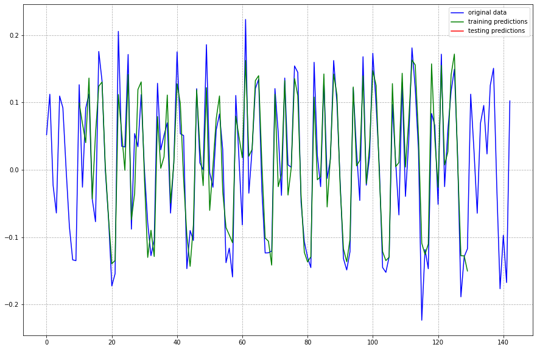

```python
# calculate root mean squared error
trainScore = math.sqrt(mean_squared_error(trainY, train_predict_pure[:, 0]))
print('Train Score: %.2f RMSE' % (trainScore))
testScore = math.sqrt(mean_squared_error(testY, test_predict_pure[:, 0]))
print('Test Score: %.2f RMSE' % (testScore))

train_predict_df = pd.DataFrame(train_predict_pure[:,0])
test_predict_df = pd.DataFrame(test_predict_pure[:,0])
predict_df = pd.concat([train_predict_df, test_predict_df])
predict_df.reset_index(inplace=True)
predict_df.drop(columns=["index"], inplace=True)

# plot baseline and predictions
plt.figure(figsize=(15, 10))
plt.plot(log_diff_data, color='b', label="original data")
plt.plot(predict_df[:len(train_predict_df)].index + 10, predict_df[:len(train_predict_df)][0], color="g",
         label='training predictions')
plt.plot(predict_df[len(train_predict_df):].index,
         predict_df[len(train_predict_df):][0], color="r", label="testing predictions")
plt.legend()
plt.grid(True, linestyle='--')
plt.show()
```

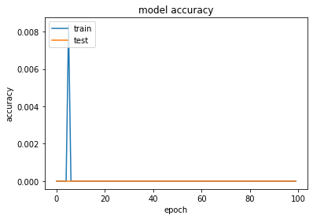

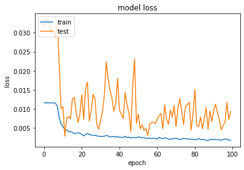

```python
plt.plot(history.history['accuracy'])
plt.plot(history.history['val_accuracy'])
plt.title('model accuracy')
plt.ylabel('accuracy')
plt.xlabel('epoch')
plt.legend(['train', 'test'], loc='upper left')
plt.show()

plt.plot(history.history['loss'])
plt.plot(history.history['val_loss'])
plt.title('model loss')
plt.ylabel('loss')
plt.xlabel('epoch')
plt.legend(['train', 'test'], loc='upper left')
plt.show()
```

```
Train Score: 74.48 RMSE
```

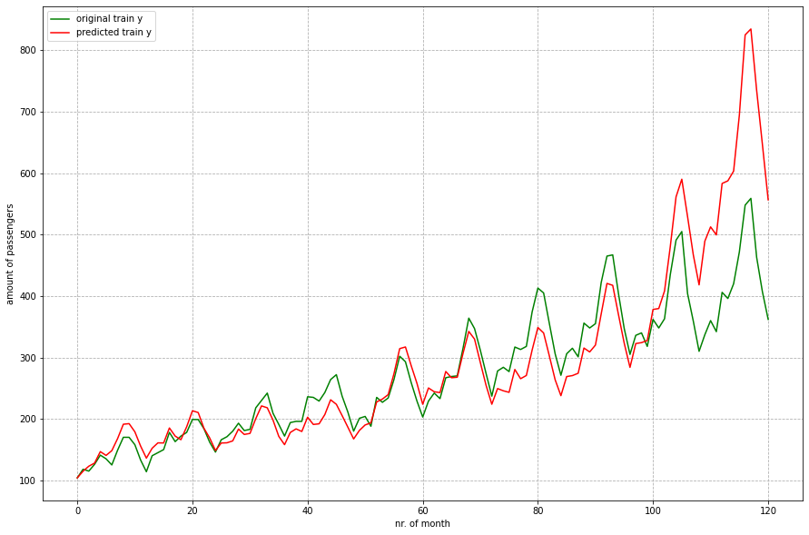

```python
data = dataset.values
data = data.astype('float32')
log_data = np.log(data)

first_train_y = log_data[look_back]
# first_test_value = log_data[train_size]

train_predictions = train_predict_pure[:,0]
train_predictions = np.insert(train_predictions, 0, first_train_y)
train_predictions = np.exp(train_predictions.cumsum())

original_train_Y = trainY
original_train_Y = np.insert(original_train_Y, 0, first_train_y)
original_train_Y = np.exp(original_train_Y.cumsum())

trainScore = math.sqrt(mean_squared_error(original_train_Y, train_predictions))
print('Train Score: %.2f RMSE' % (trainScore))

plt.figure(figsize=(15, 10))
plt.plot(original_train_Y, color='g', label='original train y')
plt.plot(train_predictions, color='r', label='predicted train y')
plt.legend()
plt.xlabel("nr. of month")
plt.ylabel("amount of passengers")
plt.grid(True, linestyle='--')
plt.show()
```

This model contains the best RMSE identifier and distribution looks extremely similar most of the time, but closer to the end predictions start to be much higher than original ones. There is also a heavy overfit (possible number is around 10 epoches)

# LSTM two layers, 100 neurons, 100 epoches, log with differential applied

```python
data = dataset.values
data = data.astype('float32')
log_data = np.log(data)

log_diff_data = np.diff(log_data, axis=0)

train_size = int(len(log_diff_data) * 0.9167)
test_size = len(log_diff_data) - train_size
train, test = log_diff_data[0:train_size,:], log_diff_data[train_size:len(log_diff_data),:]
print(len(train), len(test))

look_back = 10
trainX, trainY = create_dataset(train, look_back)
testX, testY = create_dataset(test, look_back)

trainX = np.reshape(trainX, (trainX.shape[0], 1, trainX.shape[1]))
testX = np.reshape(testX, (testX.shape[0], 1, testX.shape[1]))

model = Sequential()
# model.add(LSTM(4, input_shape=(1, look_back)))
model.add(LSTM(4, batch_input_shape=(1, 1, look_back), stateful=True, return_sequences=True))
model.add(Dense(100))
model.add(LSTM(4, batch_input_shape=(1, 1, look_back), stateful=True))
model.add(Dense(100))
model.compile(loss='mean_squared_error', optimizer='adam', metrics=['accuracy'])
history = model.fit(trainX, trainY, epochs=100, validation_data=(testX, testY), batch_size=1, verbose=2)

# make predictions
train_predict_pure = model.predict(trainX, batch_size=1)
test_predict_pure = model.predict(testX, batch_size=1)
```

```
131 12
120/120 - 4s - loss: 0.0116 - accuracy: 0.0000e+00 - val_loss: 0.0314 - val_accuracy: 0.0000e+00 - 4s/epoch - 34ms/step
120/120 - 0s - loss: 0.0116 - accuracy: 0.0000e+00 - val_loss: 0.0327 - val_accuracy: 0.0000e+00 - 299ms/epoch - 2ms/step
120/120 - 0s - loss: 0.0116 - accuracy: 0.0000e+00 - val_loss: 0.0329 - val_accuracy: 0.0000e+00 - 310ms/epoch - 3ms/step
120/120 - 0s - loss: 0.0116 - accuracy: 0.0000e+00 - val_loss: 0.0335 - val_accuracy: 0.0000e+00 - 304ms/epoch - 3ms/step
120/120 - 0s - loss: 0.0115 - accuracy: 0.0000e+00 - val_loss: 0.0285 - val_accuracy: 0.0000e+00 - 307ms/epoch - 3ms/step
120/120 - 0s - loss: 0.0115 - accuracy: 0.0000e+00 - val_loss: 0.0222 - val_accuracy: 0.0000e+00 - 304ms/epoch - 3ms/step
120/120 - 0s - loss: 0.0102 - accuracy: 0.0000e+00 - val_loss: 0.0191 - val_accuracy: 0.0000e+00 - 312ms/epoch - 3ms/step
120/120 - 0s - loss: 0.0082 - accuracy: 0.0000e+00 - val_loss: 0.0224 - val_accuracy: 0.0000e+00 - 301ms/epoch - 3ms/step
120/120 - 0s - loss: 0.0065 - accuracy: 0.0000e+00 - val_loss: 0.0035 - val_accuracy: 0.0000e+00 - 315ms/epoch - 3ms/step
120/120 - 0s - loss: 0.0058 - accuracy: 0.0000e+00 - val_loss: 0.0052 - val_accuracy: 0.0000e+00 - 316ms/epoch - 3ms/step
120/120 - 0s - loss: 0.0053 - accuracy: 0.0000e+00 - val_loss: 0.0081 - val_accuracy: 0.0000e+00 - 313ms/epoch - 3ms/step
120/120 - 0s - loss: 0.0047 - accuracy: 0.0000e+00 - val_loss: 0.0099 - val_accuracy: 0.0000e+00 - 297ms/epoch - 2ms/step
120/120 - 0s - loss: 0.0051 - accuracy: 0.0000e+00 - val_loss: 0.0068 - val_accuracy: 0.0000e+00 - 322ms/epoch - 3ms/step
120/120 - 0s - loss: 0.0047 - accuracy: 0.0000e+00 - val_loss: 0.0044 - val_accuracy: 0.0000e+00 - 326ms/epoch - 3ms/step
120/120 - 0s - loss: 0.0043 - accuracy: 0.0000e+00 - val_loss: 0.0162 - val_accuracy: 0.0000e+00 - 314ms/epoch - 3ms/step
120/120 - 0s - loss: 0.0045 - accuracy: 0.0000e+00 - val_loss: 0.0041 - val_accuracy: 0.0000e+00 - 301ms/epoch - 3ms/step
120/120 - 0s - loss: 0.0039 - accuracy: 0.0000e+00 - val_loss: 0.0320 - val_accuracy: 0.0000e+00 - 319ms/epoch - 3ms/step
120/120 - 0s - loss: 0.0042 - accuracy: 0.0000e+00 - val_loss: 0.0050 - val_accuracy: 0.0000e+00 - 311ms/epoch - 3ms/step
120/120 - 0s - loss: 0.0044 - accuracy: 0.0000e+00 - val_loss: 0.0033 - val_accuracy: 0.0000e+00 - 339ms/epoch - 3ms/step
120/120 - 0s - loss: 0.0041 - accuracy: 0.0000e+00 - val_loss: 0.0158 - val_accuracy: 0.0000e+00 - 317ms/epoch - 3ms/step
120/120 - 0s - loss: 0.0036 - accuracy: 0.0000e+00 - val_loss: 0.0059 - val_accuracy: 0.0000e+00 - 322ms/epoch - 3ms/step
120/120 - 0s - loss: 0.0037 - accuracy: 0.0000e+00 - val_loss: 0.0061 - val_accuracy: 0.0000e+00 - 301ms/epoch - 3ms/step
120/120 - 0s - loss: 0.0039 - accuracy: 0.0000e+00 - val_loss: 0.0099 - val_accuracy: 0.0000e+00 - 322ms/epoch - 3ms/step
120/120 - 0s - loss: 0.0034 - accuracy: 0.0000e+00 - val_loss: 0.0105 - val_accuracy: 0.0000e+00 - 321ms/epoch - 3ms/step
120/120 - 0s - loss: 0.0031 - accuracy: 0.0000e+00 - val_loss: 0.0055 - val_accuracy: 0.0000e+00 - 310ms/epoch - 3ms/step
120/120 - 0s - loss: 0.0035 - accuracy: 0.0000e+00 - val_loss: 0.0135 - val_accuracy: 0.0000e+00 - 308ms/epoch - 3ms/step
120/120 - 0s - loss: 0.0033 - accuracy: 0.0000e+00 - val_loss: 0.0051 - val_accuracy: 0.0000e+00 - 314ms/epoch - 3ms/step
120/120 - 0s - loss: 0.0031 - accuracy: 0.0000e+00 - val_loss: 0.0269 - val_accuracy: 0.0000e+00 - 304ms/epoch - 3ms/step
120/120 - 0s - loss: 0.0031 - accuracy: 0.0000e+00 - val_loss: 0.0079 - val_accuracy: 0.0000e+00 - 315ms/epoch - 3ms/step
120/120 - 0s - loss: 0.0031 - accuracy: 0.0000e+00 - val_loss: 0.0061 - val_accuracy: 0.0000e+00 - 324ms/epoch - 3ms/step
120/120 - 0s - loss: 0.0031 - accuracy: 0.0000e+00 - val_loss: 0.0046 - val_accuracy: 0.0000e+00 - 312ms/epoch - 3ms/step
120/120 - 0s - loss: 0.0034 - accuracy: 0.0000e+00 - val_loss: 0.0057 - val_accuracy: 0.0000e+00 - 316ms/epoch - 3ms/step
120/120 - 0s - loss: 0.0031 - accuracy: 0.0000e+00 - val_loss: 0.0072 - val_accuracy: 0.0000e+00 - 312ms/epoch - 3ms/step
120/120 - 0s - loss: 0.0027 - accuracy: 0.0000e+00 - val_loss: 0.0165 - val_accuracy: 0.0000e+00 - 312ms/epoch - 3ms/step
120/120 - 0s - loss: 0.0029 - accuracy: 0.0000e+00 - val_loss: 0.0127 - val_accuracy: 0.0000e+00 - 306ms/epoch - 3ms/step
120/120 - 0s - loss: 0.0026 - accuracy: 0.0000e+00 - val_loss: 0.0110 - val_accuracy: 0.0000e+00 - 328ms/epoch - 3ms/step
120/120 - 0s - loss: 0.0027 - accuracy: 0.0000e+00 - val_loss: 0.0148 - val_accuracy: 0.0000e+00 - 317ms/epoch - 3ms/step
120/120 - 0s - loss: 0.0027 - accuracy: 0.0000e+00 - val_loss: 0.0049 - val_accuracy: 0.0000e+00 - 317ms/epoch - 3ms/step
120/120 - 0s - loss: 0.0029 - accuracy: 0.0000e+00 - val_loss: 0.0108 - val_accuracy: 0.0000e+00 - 316ms/epoch - 3ms/step
```

[output cut: 46 more lines]

```
120/120 - 0s - loss: 0.0016 - accuracy: 0.0000e+00 - val_loss: 0.0116 - val_accuracy: 0.0000e+00 - 334ms/epoch - 3ms/step
120/120 - 0s - loss: 0.0017 - accuracy: 0.0000e+00 - val_loss: 0.0141 - val_accuracy: 0.0000e+00 - 327ms/epoch - 3ms/step
120/120 - 0s - loss: 0.0016 - accuracy: 0.0000e+00 - val_loss: 0.0065 - val_accuracy: 0.0000e+00 - 307ms/epoch - 3ms/step
120/120 - 0s - loss: 0.0018 - accuracy: 0.0000e+00 - val_loss: 0.0159 - val_accuracy: 0.0000e+00 - 330ms/epoch - 3ms/step
120/120 - 0s - loss: 0.0019 - accuracy: 0.0000e+00 - val_loss: 0.0108 - val_accuracy: 0.0000e+00 - 322ms/epoch - 3ms/step
120/120 - 0s - loss: 0.0019 - accuracy: 0.0000e+00 - val_loss: 0.0144 - val_accuracy: 0.0000e+00 - 302ms/epoch - 3ms/step
120/120 - 0s - loss: 0.0016 - accuracy: 0.0000e+00 - val_loss: 0.0144 - val_accuracy: 0.0000e+00 - 309ms/epoch - 3ms/step
120/120 - 0s - loss: 0.0017 - accuracy: 0.0000e+00 - val_loss: 0.0091 - val_accuracy: 0.0000e+00 - 334ms/epoch - 3ms/step
120/120 - 0s - loss: 0.0018 - accuracy: 0.0000e+00 - val_loss: 0.0089 - val_accuracy: 0.0000e+00 - 308ms/epoch - 3ms/step
120/120 - 0s - loss: 0.0019 - accuracy: 0.0000e+00 - val_loss: 0.0038 - val_accuracy: 0.0000e+00 - 299ms/epoch - 2ms/step
120/120 - 0s - loss: 0.0018 - accuracy: 0.0000e+00 - val_loss: 0.0081 - val_accuracy: 0.0000e+00 - 327ms/epoch - 3ms/step
120/120 - 0s - loss: 0.0017 - accuracy: 0.0000e+00 - val_loss: 0.0064 - val_accuracy: 0.0000e+00 - 305ms/epoch - 3ms/step
120/120 - 0s - loss: 0.0017 - accuracy: 0.0000e+00 - val_loss: 0.0142 - val_accuracy: 0.0000e+00 - 305ms/epoch - 3ms/step
120/120 - 0s - loss: 0.0015 - accuracy: 0.0000e+00 - val_loss: 0.0131 - val_accuracy: 0.0000e+00 - 318ms/epoch - 3ms/step
120/120 - 0s - loss: 0.0017 - accuracy: 0.0000e+00 - val_loss: 0.0094 - val_accuracy: 0.0000e+00 - 330ms/epoch - 3ms/step
```

```
Train Score: 0.04 RMSE
Test Score: 0.12 RMSE
```

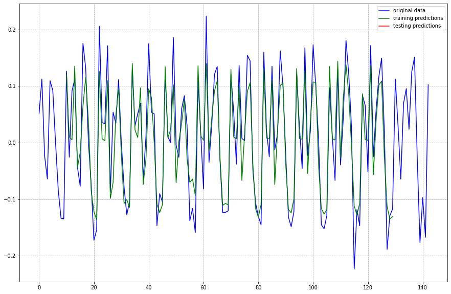

```python
# calculate root mean squared error
trainScore = math.sqrt(mean_squared_error(trainY, train_predict_pure[:, 0]))
print('Train Score: %.2f RMSE' % (trainScore))
testScore = math.sqrt(mean_squared_error(testY, test_predict_pure[:, 0]))
print('Test Score: %.2f RMSE' % (testScore))

train_predict_df = pd.DataFrame(train_predict_pure[:,0])
test_predict_df = pd.DataFrame(test_predict_pure[:,0])
predict_df = pd.concat([train_predict_df, test_predict_df])
predict_df.reset_index(inplace=True)
predict_df.drop(columns=["index"], inplace=True)

# plot baseline and predictions
plt.figure(figsize=(15, 10))
plt.plot(log_diff_data, color='b', label="original data")
plt.plot(predict_df[:len(train_predict_df)].index + 10, predict_df[:len(train_predict_df)][0], color="g",
         label='training predictions')
plt.plot(predict_df[len(train_predict_df):].index,
         predict_df[len(train_predict_df):][0], color="r", label="testing predictions")
plt.legend()
plt.grid(True, linestyle='--')
plt.show()
```

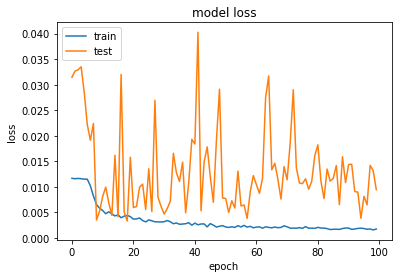

```python
plt.plot(history.history['accuracy'])
plt.plot(history.history['val_accuracy'])
plt.title('model accuracy')
plt.ylabel('accuracy')
plt.xlabel('epoch')
plt.legend(['train', 'test'], loc='upper left')
plt.show()

plt.plot(history.history['loss'])
plt.plot(history.history['val_loss'])
plt.title('model loss')
plt.ylabel('loss')
plt.xlabel('epoch')
plt.legend(['train', 'test'], loc='upper left')
plt.show()
```

[output not shown]

```
Train Score: 140.65 RMSE
```

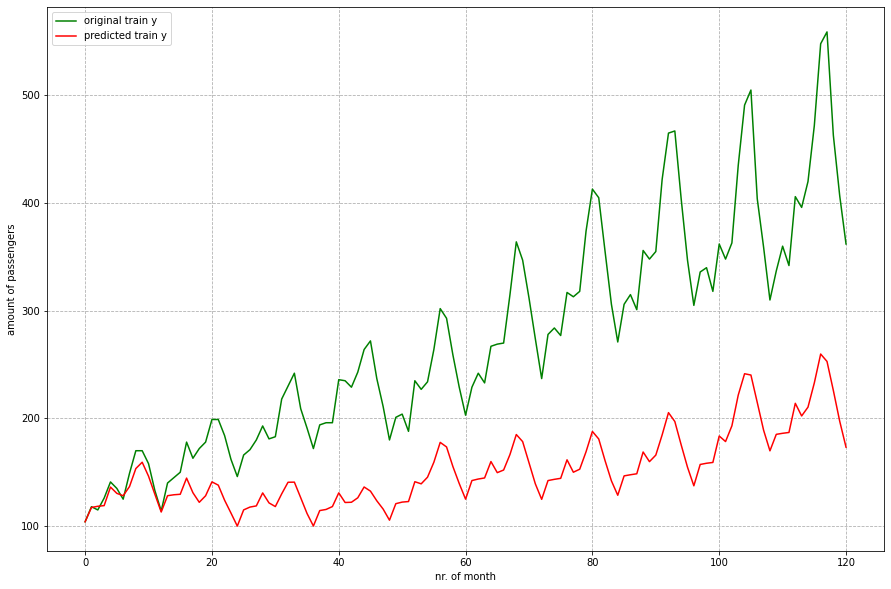

```python
data = dataset.values
data = data.astype('float32')
log_data = np.log(data)

first_train_y = log_data[look_back]
# first_test_value = log_data[train_size]

train_predictions = train_predict_pure[:,0]
train_predictions = np.insert(train_predictions, 0, first_train_y)
train_predictions = np.exp(train_predictions.cumsum())

original_train_Y = trainY
original_train_Y = np.insert(original_train_Y, 0, first_train_y)
original_train_Y = np.exp(original_train_Y.cumsum())

trainScore = math.sqrt(mean_squared_error(original_train_Y, train_predictions))
print('Train Score: %.2f RMSE' % (trainScore))

plt.figure(figsize=(15, 10))
plt.plot(original_train_Y, color='g', label='original train y')
plt.plot(train_predictions, color='r', label='predicted train y')
plt.legend()
plt.xlabel("nr. of month")
plt.ylabel("amount of passengers")
plt.grid(True, linestyle='--')
plt.show()
```

# LSTM three layers, 50 neurons, 100 epoches, log with differential applied

```python
data = dataset.values
data = data.astype('float32')
log_data = np.log(data)

log_diff_data = np.diff(log_data, axis=0)

train_size = int(len(log_diff_data) * 0.9167)
test_size = len(log_diff_data) - train_size
train, test = log_diff_data[0:train_size,:], log_diff_data[train_size:len(log_diff_data),:]
print(len(train), len(test))

look_back = 10
trainX, trainY = create_dataset(train, look_back)
testX, testY = create_dataset(test, look_back)

trainX = np.reshape(trainX, (trainX.shape[0], 1, trainX.shape[1]))
testX = np.reshape(testX, (testX.shape[0], 1, testX.shape[1]))

model = Sequential()
# model.add(LSTM(4, input_shape=(1, look_back)))
model.add(LSTM(4, batch_input_shape=(1, 1, look_back), stateful=True, return_sequences=True))
model.add(Dense(50))
model.add(LSTM(4, batch_input_shape=(1, 1, look_back), stateful=True, return_sequences=True))
model.add(Dense(50))
model.add(LSTM(4, batch_input_shape=(1, 1, look_back), stateful=True))
model.add(Dense(50))
model.compile(loss='mean_squared_error', optimizer='adam', metrics=['accuracy'])
history = model.fit(trainX, trainY, epochs=100, validation_data=(testX, testY), batch_size=1, verbose=2)

# make predictions
train_predict_pure = model.predict(trainX, batch_size=1)
test_predict_pure = model.predict(testX, batch_size=1)
```

```
131 12
120/120 - 6s - loss: 0.0117 - accuracy: 0.0000e+00 - val_loss: 0.0314 - val_accuracy: 0.0000e+00 - 6s/epoch - 51ms/step
120/120 - 0s - loss: 0.0116 - accuracy: 0.0000e+00 - val_loss: 0.0323 - val_accuracy: 0.0000e+00 - 394ms/epoch - 3ms/step
120/120 - 0s - loss: 0.0116 - accuracy: 0.0000e+00 - val_loss: 0.0330 - val_accuracy: 0.0000e+00 - 389ms/epoch - 3ms/step
120/120 - 0s - loss: 0.0116 - accuracy: 0.0000e+00 - val_loss: 0.0321 - val_accuracy: 0.0000e+00 - 384ms/epoch - 3ms/step
120/120 - 0s - loss: 0.0116 - accuracy: 0.0000e+00 - val_loss: 0.0312 - val_accuracy: 0.0000e+00 - 383ms/epoch - 3ms/step
120/120 - 0s - loss: 0.0116 - accuracy: 0.0000e+00 - val_loss: 0.0319 - val_accuracy: 0.0000e+00 - 378ms/epoch - 3ms/step
120/120 - 0s - loss: 0.0116 - accuracy: 0.0000e+00 - val_loss: 0.0317 - val_accuracy: 0.0000e+00 - 376ms/epoch - 3ms/step
120/120 - 0s - loss: 0.0116 - accuracy: 0.0000e+00 - val_loss: 0.0325 - val_accuracy: 0.0000e+00 - 416ms/epoch - 3ms/step
120/120 - 0s - loss: 0.0116 - accuracy: 0.0000e+00 - val_loss: 0.0317 - val_accuracy: 0.0000e+00 - 414ms/epoch - 3ms/step
120/120 - 0s - loss: 0.0115 - accuracy: 0.0000e+00 - val_loss: 0.0322 - val_accuracy: 0.0000e+00 - 405ms/epoch - 3ms/step
120/120 - 0s - loss: 0.0116 - accuracy: 0.0000e+00 - val_loss: 0.0315 - val_accuracy: 0.0000e+00 - 397ms/epoch - 3ms/step
120/120 - 0s - loss: 0.0115 - accuracy: 0.0000e+00 - val_loss: 0.0305 - val_accuracy: 0.0000e+00 - 405ms/epoch - 3ms/step
120/120 - 0s - loss: 0.0116 - accuracy: 0.0000e+00 - val_loss: 0.0316 - val_accuracy: 0.0000e+00 - 403ms/epoch - 3ms/step
120/120 - 0s - loss: 0.0116 - accuracy: 0.0000e+00 - val_loss: 0.0301 - val_accuracy: 0.0000e+00 - 396ms/epoch - 3ms/step
120/120 - 0s - loss: 0.0116 - accuracy: 0.0000e+00 - val_loss: 0.0312 - val_accuracy: 0.0000e+00 - 384ms/epoch - 3ms/step
120/120 - 0s - loss: 0.0114 - accuracy: 0.0000e+00 - val_loss: 0.0204 - val_accuracy: 0.0000e+00 - 397ms/epoch - 3ms/step
120/120 - 0s - loss: 0.0069 - accuracy: 0.0000e+00 - val_loss: 0.0161 - val_accuracy: 0.0000e+00 - 386ms/epoch - 3ms/step
120/120 - 0s - loss: 0.0055 - accuracy: 0.0000e+00 - val_loss: 0.0048 - val_accuracy: 0.0000e+00 - 399ms/epoch - 3ms/step
120/120 - 0s - loss: 0.0050 - accuracy: 0.0000e+00 - val_loss: 0.0062 - val_accuracy: 0.0000e+00 - 404ms/epoch - 3ms/step
120/120 - 0s - loss: 0.0050 - accuracy: 0.0000e+00 - val_loss: 0.0043 - val_accuracy: 0.0000e+00 - 396ms/epoch - 3ms/step
120/120 - 0s - loss: 0.0044 - accuracy: 0.0000e+00 - val_loss: 0.0205 - val_accuracy: 0.0000e+00 - 440ms/epoch - 4ms/step
120/120 - 0s - loss: 0.0045 - accuracy: 0.0000e+00 - val_loss: 0.0035 - val_accuracy: 0.0000e+00 - 433ms/epoch - 4ms/step
120/120 - 0s - loss: 0.0045 - accuracy: 0.0000e+00 - val_loss: 0.0061 - val_accuracy: 0.0000e+00 - 424ms/epoch - 4ms/step
120/120 - 0s - loss: 0.0043 - accuracy: 0.0000e+00 - val_loss: 0.0098 - val_accuracy: 0.0000e+00 - 404ms/epoch - 3ms/step
120/120 - 0s - loss: 0.0043 - accuracy: 0.0000e+00 - val_loss: 0.0062 - val_accuracy: 0.0000e+00 - 396ms/epoch - 3ms/step
120/120 - 0s - loss: 0.0041 - accuracy: 0.0000e+00 - val_loss: 0.0104 - val_accuracy: 0.0000e+00 - 402ms/epoch - 3ms/step
120/120 - 0s - loss: 0.0041 - accuracy: 0.0000e+00 - val_loss: 0.0064 - val_accuracy: 0.0000e+00 - 387ms/epoch - 3ms/step
120/120 - 0s - loss: 0.0046 - accuracy: 0.0000e+00 - val_loss: 0.0143 - val_accuracy: 0.0000e+00 - 395ms/epoch - 3ms/step
120/120 - 0s - loss: 0.0042 - accuracy: 0.0000e+00 - val_loss: 0.0089 - val_accuracy: 0.0000e+00 - 385ms/epoch - 3ms/step
120/120 - 0s - loss: 0.0043 - accuracy: 0.0000e+00 - val_loss: 0.0076 - val_accuracy: 0.0000e+00 - 380ms/epoch - 3ms/step
120/120 - 0s - loss: 0.0041 - accuracy: 0.0000e+00 - val_loss: 0.0052 - val_accuracy: 0.0000e+00 - 392ms/epoch - 3ms/step
120/120 - 0s - loss: 0.0041 - accuracy: 0.0000e+00 - val_loss: 0.0075 - val_accuracy: 0.0000e+00 - 398ms/epoch - 3ms/step
120/120 - 0s - loss: 0.0041 - accuracy: 0.0000e+00 - val_loss: 0.0079 - val_accuracy: 0.0000e+00 - 411ms/epoch - 3ms/step
120/120 - 0s - loss: 0.0041 - accuracy: 0.0000e+00 - val_loss: 0.0143 - val_accuracy: 0.0000e+00 - 398ms/epoch - 3ms/step
120/120 - 0s - loss: 0.0040 - accuracy: 0.0000e+00 - val_loss: 0.0118 - val_accuracy: 0.0000e+00 - 401ms/epoch - 3ms/step
120/120 - 0s - loss: 0.0039 - accuracy: 0.0000e+00 - val_loss: 0.0086 - val_accuracy: 0.0000e+00 - 402ms/epoch - 3ms/step
120/120 - 0s - loss: 0.0038 - accuracy: 0.0000e+00 - val_loss: 0.0108 - val_accuracy: 0.0000e+00 - 404ms/epoch - 3ms/step
120/120 - 0s - loss: 0.0040 - accuracy: 0.0000e+00 - val_loss: 0.0057 - val_accuracy: 0.0000e+00 - 409ms/epoch - 3ms/step
120/120 - 0s - loss: 0.0040 - accuracy: 0.0000e+00 - val_loss: 0.0105 - val_accuracy: 0.0000e+00 - 392ms/epoch - 3ms/step
```

[output cut: 46 more lines]

```
120/120 - 0s - loss: 0.0020 - accuracy: 0.0000e+00 - val_loss: 0.0126 - val_accuracy: 0.0000e+00 - 413ms/epoch - 3ms/step
120/120 - 0s - loss: 0.0021 - accuracy: 0.0000e+00 - val_loss: 0.0186 - val_accuracy: 0.0000e+00 - 406ms/epoch - 3ms/step
120/120 - 0s - loss: 0.0021 - accuracy: 0.0000e+00 - val_loss: 0.0100 - val_accuracy: 0.0000e+00 - 405ms/epoch - 3ms/step
120/120 - 0s - loss: 0.0021 - accuracy: 0.0000e+00 - val_loss: 0.0065 - val_accuracy: 0.0000e+00 - 400ms/epoch - 3ms/step
120/120 - 0s - loss: 0.0025 - accuracy: 0.0000e+00 - val_loss: 0.0089 - val_accuracy: 0.0000e+00 - 405ms/epoch - 3ms/step
120/120 - 0s - loss: 0.0024 - accuracy: 0.0000e+00 - val_loss: 0.0079 - val_accuracy: 0.0000e+00 - 391ms/epoch - 3ms/step
120/120 - 0s - loss: 0.0022 - accuracy: 0.0000e+00 - val_loss: 0.0105 - val_accuracy: 0.0000e+00 - 414ms/epoch - 3ms/step
120/120 - 0s - loss: 0.0022 - accuracy: 0.0000e+00 - val_loss: 0.0057 - val_accuracy: 0.0000e+00 - 433ms/epoch - 4ms/step
120/120 - 0s - loss: 0.0023 - accuracy: 0.0000e+00 - val_loss: 0.0100 - val_accuracy: 0.0000e+00 - 396ms/epoch - 3ms/step
120/120 - 0s - loss: 0.0022 - accuracy: 0.0000e+00 - val_loss: 7.0255e-04 - val_accuracy: 0.0000e+00 - 413ms/epoch - 3ms/step
120/120 - 0s - loss: 0.0026 - accuracy: 0.0000e+00 - val_loss: 0.0035 - val_accuracy: 0.0000e+00 - 402ms/epoch - 3ms/step
120/120 - 0s - loss: 0.0021 - accuracy: 0.0000e+00 - val_loss: 0.0027 - val_accuracy: 0.0000e+00 - 402ms/epoch - 3ms/step
120/120 - 0s - loss: 0.0020 - accuracy: 0.0000e+00 - val_loss: 0.0109 - val_accuracy: 0.0000e+00 - 383ms/epoch - 3ms/step
120/120 - 0s - loss: 0.0019 - accuracy: 0.0000e+00 - val_loss: 0.0124 - val_accuracy: 0.0000e+00 - 393ms/epoch - 3ms/step
120/120 - 0s - loss: 0.0021 - accuracy: 0.0000e+00 - val_loss: 0.0056 - val_accuracy: 0.0000e+00 - 394ms/epoch - 3ms/step
```

```
Train Score: 0.05 RMSE
Test Score: 0.10 RMSE
```

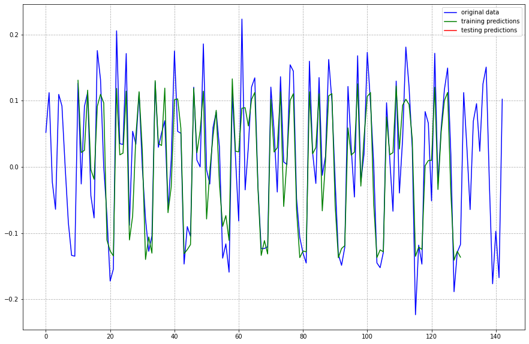

```python
# calculate root mean squared error
trainScore = math.sqrt(mean_squared_error(trainY, train_predict_pure[:, 0]))
print('Train Score: %.2f RMSE' % (trainScore))
testScore = math.sqrt(mean_squared_error(testY, test_predict_pure[:, 0]))
print('Test Score: %.2f RMSE' % (testScore))

train_predict_df = pd.DataFrame(train_predict_pure[:,0])
test_predict_df = pd.DataFrame(test_predict_pure[:,0])
predict_df = pd.concat([train_predict_df, test_predict_df])
predict_df.reset_index(inplace=True)
predict_df.drop(columns=["index"], inplace=True)

# plot baseline and predictions
plt.figure(figsize=(15, 10))
plt.plot(log_diff_data, color='b', label="original data")
plt.plot(predict_df[:len(train_predict_df)].index + 10, predict_df[:len(train_predict_df)][0], color="g",
         label='training predictions')
plt.plot(predict_df[len(train_predict_df):].index,
         predict_df[len(train_predict_df):][0], color="r", label="testing predictions")
plt.legend()
plt.grid(True, linestyle='--')
plt.show()
```

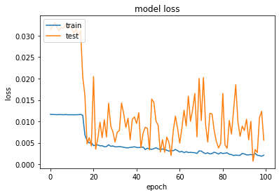

```python
plt.plot(history.history['accuracy'])
plt.plot(history.history['val_accuracy'])
plt.title('model accuracy')
plt.ylabel('accuracy')
plt.xlabel('epoch')
plt.legend(['train', 'test'], loc='upper left')
plt.show()

plt.plot(history.history['loss'])
plt.plot(history.history['val_loss'])
plt.title('model loss')
plt.ylabel('loss')
plt.xlabel('epoch')
plt.legend(['train', 'test'], loc='upper left')
plt.show()
```

[output not shown]

```
Train Score: 108.07 RMSE
```

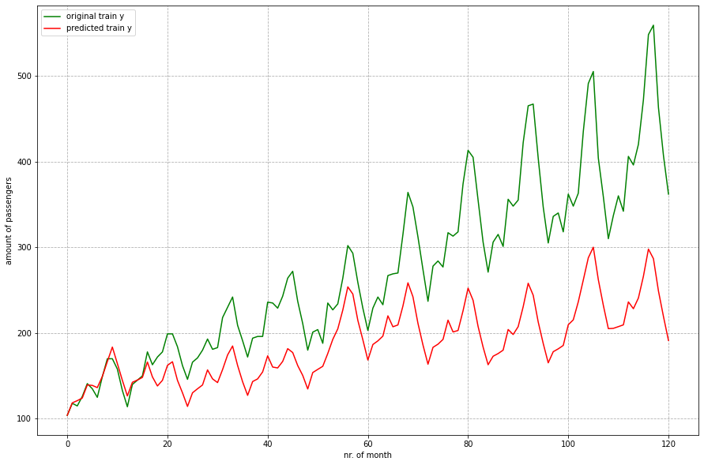

```python
data = dataset.values
data = data.astype('float32')
log_data = np.log(data)

first_train_y = log_data[look_back]
# first_test_value = log_data[train_size]

train_predictions = train_predict_pure[:,0]
train_predictions = np.insert(train_predictions, 0, first_train_y)
train_predictions = np.exp(train_predictions.cumsum())

original_train_Y = trainY
original_train_Y = np.insert(original_train_Y, 0, first_train_y)
original_train_Y = np.exp(original_train_Y.cumsum())

trainScore = math.sqrt(mean_squared_error(original_train_Y, train_predictions))
print('Train Score: %.2f RMSE' % (trainScore))

plt.figure(figsize=(15, 10))
plt.plot(original_train_Y, color='g', label='original train y')
plt.plot(train_predictions, color='r', label='predicted train y')
plt.legend()
plt.xlabel("nr. of month")
plt.ylabel("amount of passengers")
plt.grid(True, linestyle='--')
plt.show()
```

Better match of the current model predictions compared to the previous one, desired number of epoches is around 18

# LSTM three layers, 100 neurons, 100 epoches, log with differential applied

```python
data = dataset.values
data = data.astype('float32')
log_data = np.log(data)

log_diff_data = np.diff(log_data, axis=0)

train_size = int(len(log_diff_data) * 0.9167)
test_size = len(log_diff_data) - train_size
train, test = log_diff_data[0:train_size,:], log_diff_data[train_size:len(log_diff_data),:]
print(len(train), len(test))

look_back = 10
trainX, trainY = create_dataset(train, look_back)
testX, testY = create_dataset(test, look_back)

trainX = np.reshape(trainX, (trainX.shape[0], 1, trainX.shape[1]))
testX = np.reshape(testX, (testX.shape[0], 1, testX.shape[1]))

model = Sequential()
# model.add(LSTM(4, input_shape=(1, look_back)))
model.add(LSTM(4, batch_input_shape=(1, 1, look_back), stateful=True, return_sequences=True))
model.add(Dense(100))
model.add(LSTM(4, batch_input_shape=(1, 1, look_back), stateful=True, return_sequences=True))
model.add(Dense(100))
model.add(LSTM(4, batch_input_shape=(1, 1, look_back), stateful=True))
model.add(Dense(100))
model.compile(loss='mean_squared_error', optimizer='adam', metrics=['accuracy'])
history = model.fit(trainX, trainY, epochs=100, validation_data=(testX, testY), batch_size=1, verbose=2)

# make predictions
train_predict_pure = model.predict(trainX, batch_size=1)
test_predict_pure = model.predict(testX, batch_size=1)
```

```
131 12
120/120 - 6s - loss: 0.0117 - accuracy: 0.0000e+00 - val_loss: 0.0316 - val_accuracy: 0.0000e+00 - 6s/epoch - 50ms/step
120/120 - 0s - loss: 0.0116 - accuracy: 0.0000e+00 - val_loss: 0.0325 - val_accuracy: 0.0000e+00 - 413ms/epoch - 3ms/step
120/120 - 0s - loss: 0.0116 - accuracy: 0.0000e+00 - val_loss: 0.0331 - val_accuracy: 0.0000e+00 - 439ms/epoch - 4ms/step
120/120 - 1s - loss: 0.0116 - accuracy: 0.0000e+00 - val_loss: 0.0323 - val_accuracy: 0.0000e+00 - 840ms/epoch - 7ms/step
120/120 - 1s - loss: 0.0116 - accuracy: 0.0000e+00 - val_loss: 0.0312 - val_accuracy: 0.0000e+00 - 708ms/epoch - 6ms/step
120/120 - 1s - loss: 0.0116 - accuracy: 0.0000e+00 - val_loss: 0.0319 - val_accuracy: 0.0000e+00 - 824ms/epoch - 7ms/step
120/120 - 1s - loss: 0.0116 - accuracy: 0.0000e+00 - val_loss: 0.0317 - val_accuracy: 0.0000e+00 - 820ms/epoch - 7ms/step
120/120 - 1s - loss: 0.0116 - accuracy: 0.0000e+00 - val_loss: 0.0325 - val_accuracy: 0.0000e+00 - 801ms/epoch - 7ms/step
120/120 - 1s - loss: 0.0116 - accuracy: 0.0000e+00 - val_loss: 0.0317 - val_accuracy: 0.0000e+00 - 765ms/epoch - 6ms/step
120/120 - 1s - loss: 0.0115 - accuracy: 0.0000e+00 - val_loss: 0.0322 - val_accuracy: 0.0000e+00 - 699ms/epoch - 6ms/step
120/120 - 1s - loss: 0.0116 - accuracy: 0.0000e+00 - val_loss: 0.0316 - val_accuracy: 0.0000e+00 - 683ms/epoch - 6ms/step
120/120 - 1s - loss: 0.0115 - accuracy: 0.0000e+00 - val_loss: 0.0305 - val_accuracy: 0.0000e+00 - 768ms/epoch - 6ms/step
120/120 - 1s - loss: 0.0116 - accuracy: 0.0000e+00 - val_loss: 0.0316 - val_accuracy: 0.0000e+00 - 737ms/epoch - 6ms/step
120/120 - 1s - loss: 0.0116 - accuracy: 0.0000e+00 - val_loss: 0.0299 - val_accuracy: 0.0000e+00 - 651ms/epoch - 5ms/step
120/120 - 1s - loss: 0.0116 - accuracy: 0.0000e+00 - val_loss: 0.0312 - val_accuracy: 0.0000e+00 - 728ms/epoch - 6ms/step
120/120 - 1s - loss: 0.0115 - accuracy: 0.0000e+00 - val_loss: 0.0311 - val_accuracy: 0.0000e+00 - 629ms/epoch - 5ms/step
120/120 - 1s - loss: 0.0116 - accuracy: 0.0000e+00 - val_loss: 0.0315 - val_accuracy: 0.0000e+00 - 689ms/epoch - 6ms/step
120/120 - 1s - loss: 0.0115 - accuracy: 0.0000e+00 - val_loss: 0.0321 - val_accuracy: 0.0000e+00 - 712ms/epoch - 6ms/step
120/120 - 1s - loss: 0.0112 - accuracy: 0.0000e+00 - val_loss: 0.0288 - val_accuracy: 0.0000e+00 - 722ms/epoch - 6ms/step
120/120 - 1s - loss: 0.0097 - accuracy: 0.0000e+00 - val_loss: 0.0200 - val_accuracy: 0.0000e+00 - 687ms/epoch - 6ms/step
120/120 - 1s - loss: 0.0078 - accuracy: 0.0000e+00 - val_loss: 0.0280 - val_accuracy: 0.0000e+00 - 669ms/epoch - 6ms/step
120/120 - 1s - loss: 0.0055 - accuracy: 0.0000e+00 - val_loss: 0.0069 - val_accuracy: 0.0000e+00 - 1s/epoch - 9ms/step
120/120 - 1s - loss: 0.0047 - accuracy: 0.0000e+00 - val_loss: 0.0095 - val_accuracy: 0.0000e+00 - 695ms/epoch - 6ms/step
120/120 - 1s - loss: 0.0047 - accuracy: 0.0000e+00 - val_loss: 0.0049 - val_accuracy: 0.0000e+00 - 688ms/epoch - 6ms/step
120/120 - 1s - loss: 0.0042 - accuracy: 0.0000e+00 - val_loss: 0.0044 - val_accuracy: 0.0000e+00 - 715ms/epoch - 6ms/step
120/120 - 1s - loss: 0.0041 - accuracy: 0.0000e+00 - val_loss: 0.0055 - val_accuracy: 0.0000e+00 - 667ms/epoch - 6ms/step
120/120 - 1s - loss: 0.0040 - accuracy: 0.0000e+00 - val_loss: 0.0088 - val_accuracy: 0.0000e+00 - 738ms/epoch - 6ms/step
120/120 - 1s - loss: 0.0038 - accuracy: 0.0000e+00 - val_loss: 0.0075 - val_accuracy: 0.0000e+00 - 546ms/epoch - 5ms/step
120/120 - 0s - loss: 0.0038 - accuracy: 0.0000e+00 - val_loss: 0.0118 - val_accuracy: 0.0000e+00 - 418ms/epoch - 3ms/step
120/120 - 0s - loss: 0.0037 - accuracy: 0.0000e+00 - val_loss: 0.0060 - val_accuracy: 0.0000e+00 - 403ms/epoch - 3ms/step
120/120 - 0s - loss: 0.0035 - accuracy: 0.0000e+00 - val_loss: 0.0037 - val_accuracy: 0.0000e+00 - 406ms/epoch - 3ms/step
120/120 - 0s - loss: 0.0037 - accuracy: 0.0000e+00 - val_loss: 0.0053 - val_accuracy: 0.0000e+00 - 448ms/epoch - 4ms/step
120/120 - 0s - loss: 0.0033 - accuracy: 0.0000e+00 - val_loss: 0.0071 - val_accuracy: 0.0000e+00 - 409ms/epoch - 3ms/step
120/120 - 0s - loss: 0.0034 - accuracy: 0.0000e+00 - val_loss: 0.0116 - val_accuracy: 0.0000e+00 - 457ms/epoch - 4ms/step
120/120 - 0s - loss: 0.0033 - accuracy: 0.0000e+00 - val_loss: 0.0040 - val_accuracy: 0.0000e+00 - 417ms/epoch - 3ms/step
120/120 - 0s - loss: 0.0030 - accuracy: 0.0000e+00 - val_loss: 0.0159 - val_accuracy: 0.0000e+00 - 415ms/epoch - 3ms/step
120/120 - 0s - loss: 0.0029 - accuracy: 0.0000e+00 - val_loss: 0.0086 - val_accuracy: 0.0000e+00 - 435ms/epoch - 4ms/step
120/120 - 0s - loss: 0.0030 - accuracy: 0.0000e+00 - val_loss: 0.0018 - val_accuracy: 0.0000e+00 - 425ms/epoch - 4ms/step
120/120 - 0s - loss: 0.0029 - accuracy: 0.0000e+00 - val_loss: 0.0081 - val_accuracy: 0.0000e+00 - 444ms/epoch - 4ms/step
```

[output cut: 46 more lines]

```
120/120 - 0s - loss: 0.0013 - accuracy: 0.0000e+00 - val_loss: 0.0019 - val_accuracy: 0.0000e+00 - 432ms/epoch - 4ms/step
120/120 - 0s - loss: 0.0014 - accuracy: 0.0000e+00 - val_loss: 0.0051 - val_accuracy: 0.0000e+00 - 423ms/epoch - 4ms/step
120/120 - 0s - loss: 0.0017 - accuracy: 0.0000e+00 - val_loss: 0.0040 - val_accuracy: 0.0000e+00 - 422ms/epoch - 4ms/step
120/120 - 0s - loss: 0.0016 - accuracy: 0.0000e+00 - val_loss: 0.0059 - val_accuracy: 0.0000e+00 - 396ms/epoch - 3ms/step
120/120 - 0s - loss: 0.0014 - accuracy: 0.0000e+00 - val_loss: 0.0016 - val_accuracy: 0.0000e+00 - 409ms/epoch - 3ms/step
120/120 - 0s - loss: 0.0014 - accuracy: 0.0000e+00 - val_loss: 0.0040 - val_accuracy: 0.0000e+00 - 438ms/epoch - 4ms/step
120/120 - 0s - loss: 0.0013 - accuracy: 0.0000e+00 - val_loss: 0.0053 - val_accuracy: 0.0000e+00 - 431ms/epoch - 4ms/step
120/120 - 0s - loss: 0.0013 - accuracy: 0.0000e+00 - val_loss: 0.0032 - val_accuracy: 0.0000e+00 - 417ms/epoch - 3ms/step
120/120 - 0s - loss: 0.0014 - accuracy: 0.0000e+00 - val_loss: 0.0032 - val_accuracy: 0.0000e+00 - 445ms/epoch - 4ms/step
120/120 - 0s - loss: 0.0013 - accuracy: 0.0000e+00 - val_loss: 0.0026 - val_accuracy: 0.0000e+00 - 420ms/epoch - 4ms/step
120/120 - 0s - loss: 0.0013 - accuracy: 0.0000e+00 - val_loss: 0.0023 - val_accuracy: 0.0000e+00 - 427ms/epoch - 4ms/step
120/120 - 0s - loss: 0.0014 - accuracy: 0.0000e+00 - val_loss: 0.0021 - val_accuracy: 0.0000e+00 - 414ms/epoch - 3ms/step
120/120 - 0s - loss: 0.0015 - accuracy: 0.0000e+00 - val_loss: 0.0078 - val_accuracy: 0.0000e+00 - 417ms/epoch - 3ms/step
120/120 - 0s - loss: 0.0013 - accuracy: 0.0000e+00 - val_loss: 0.0020 - val_accuracy: 0.0000e+00 - 404ms/epoch - 3ms/step
120/120 - 0s - loss: 0.0013 - accuracy: 0.0000e+00 - val_loss: 0.0033 - val_accuracy: 0.0000e+00 - 396ms/epoch - 3ms/step
```